# Practical Machine Leaning Peer Assignment -Weight Lifting Excercise Prediction

Nobumasa Hayashi

11/30/2020

## Executive summary

This analysis has been done in order to predict the manner in barbell lifting. The data were collected from 6 participants. They were asked to perform weight lifting in 5 different ways. Then, the outcome variable has five classes and the total number of predictors are 159. The model constructed by the method of random forest shows the overall accuracy of 99.2% and the out-of-sample error of 0.8%.

## Preparation

```r
library(caret)
library(randomForest)
library(parallel)
library(doParallel)
```

## Data loading

```r
URL1 <- "https://d396qusza40orc.cloudfront.net/predmachlearn/pml-training.csv"
URL2 <- "https://d396qusza40orc.cloudfront.net/predmachlearn/pml-testing.csv"

filename1 <- "pml-training.csv"
filename2 <- "pml-testing.csv"

download.file(url=URL1, destfile = filename1, method ="curl")
download.file(url=URL2, destfile = filename2, method ="curl")

training<-read.csv("pml-training.csv", row.names=1, na.strings="")
testing<-read.csv("pml-testing.csv", row.names=1, na.strings="NA")
```

## Preprocess

First, we have to remove the variables that have close to zero variance in both training and testing data sets, and then remove the columns with missing values to avoid issues in training models.

```r
#Remove near zero values
nsv<-nearZeroVar(training,saveMetrics=TRUE)
training<-training[,!nsv$nzv]
testing<-testing[,!nsv$nzv]
dim(training)
```

```
## [1] 19622    75
```

```r
dim(testing)
```

```
## [1] 20 75
```

```r
#Remove variables with missing values
training_fna <- training[,colSums(is.na(training))==0]
testing_fna <- testing[,colSums(is.na(testing))==0]
dim(training_fna)
```

```
## [1] 19622    58
```

```r
dim(testing_fna)
```

```
## [1] 20 58
```

```r
#Remove unnecessary columns
colRm_tr<-c("user_name", "raw_timestamp_part_1","raw_timestamp_part_2", "cvtd_timestamp", "num_window")
colRm_test<-c("user_name", "raw_timestamp_part_1","raw_timestamp_part_2", "cvtd_timestamp","num_window", "problem_id")
training_rm <- training_fna[,!(names(training_fna) %in% colRm_tr)]
testing_rm <- testing_fna[,!(names(testing_fna) %in% colRm_test)]
dim(training_rm)
```

```
## [1] 19622    53
```

```r
dim(testing_rm)
```

```
## [1] 20 52
```

Now we split the preprocessed training data set into training set and validation set.

```r
inTrain <- createDataPartition(y=training_rm$classe,
                               p=0.7, list=FALSE)
training_ml <- training_rm[inTrain,]
validation_ml <- training_rm[-inTrain,]
training_ml$classe <- factor(training_ml$classe)
validation_ml$classe <- factor(validation_ml$classe)
dim(training_ml)
```

```
## [1] 13737    53
```

```r
dim(validation_ml)
```

```
## [1] 5885   53
```

```r
cor<-abs(sapply(colnames(training_ml[,-ncol(training)]), function(x) cor(as.numeric(training_ml[,x]), as.numeric(factor(training_ml$classe)), method="spearman")))
```

## Random Forest Model

Here, we fit a random forest model. Since this type of model is computationally expensive, parallel processing method in caret is conducted with the “parallel” and “doParallel” packages. In the following code, first, the parallel back-end processors are registered. Then, random forest model is trained with the new training data set. After the heavy calculation, parallel processing cluster is de-registered.

```r
#Register the parallel backend processors
cluster <- makeCluster(detectCores()-1)
registerDoParallel(cluster)

#train the model by Random forest method
set.seed(100)
fit_rf <- train(classe ~ ., data = training_ml, method ="rf",
                verbose = TRUE, trControl = trainControl(method = "cv", number = 3))
#De-register the parallel processing cluster
stopCluster(cluster)
registerDoSEQ()

#predict the manner in weight lifting
pred_rf <- predict(fit_rf, validation_ml)
confusionM_rf <-confusionMatrix(pred_rf, validation_ml$classe)
confusionM_rf
```

```
## Confusion Matrix and Statistics
##
##           Reference
## Prediction    A    B    C    D    E
##          A 1674    7    0    0    0
##          B    0 1123    6    0    0
##          C    0    9 1019   21    0
##          D    0    0    1  943    1
##          E    0    0    0    0 1081
##
## Overall Statistics
##
##                Accuracy : 0.9924
##                  95% CI : (0.9898, 0.9944)
##     No Information Rate : 0.2845
##     P-Value [Acc > NIR] : < 2.2e-16
##
##                   Kappa : 0.9903
##
##  Mcnemar's Test P-Value : NA
##
## Statistics by Class:
##
##                      Class: A Class: B Class: C Class: D Class: E
## Sensitivity            1.0000   0.9860   0.9932   0.9782   0.9991
## Specificity            0.9983   0.9987   0.9938   0.9996   1.0000
## Pos Pred Value         0.9958   0.9947   0.9714   0.9979   1.0000
## Neg Pred Value         1.0000   0.9966   0.9986   0.9957   0.9998
## Prevalence             0.2845   0.1935   0.1743   0.1638   0.1839
## Detection Rate         0.2845   0.1908   0.1732   0.1602   0.1837
## Detection Prevalence   0.2856   0.1918   0.1782   0.1606   0.1837
## Balanced Accuracy      0.9992   0.9923   0.9935   0.9889   0.9995
```

The constructed model is applied to the validation data set. The overall accuracy is 99.2% and the out-of-sample error is 0.8%, which is quite low.

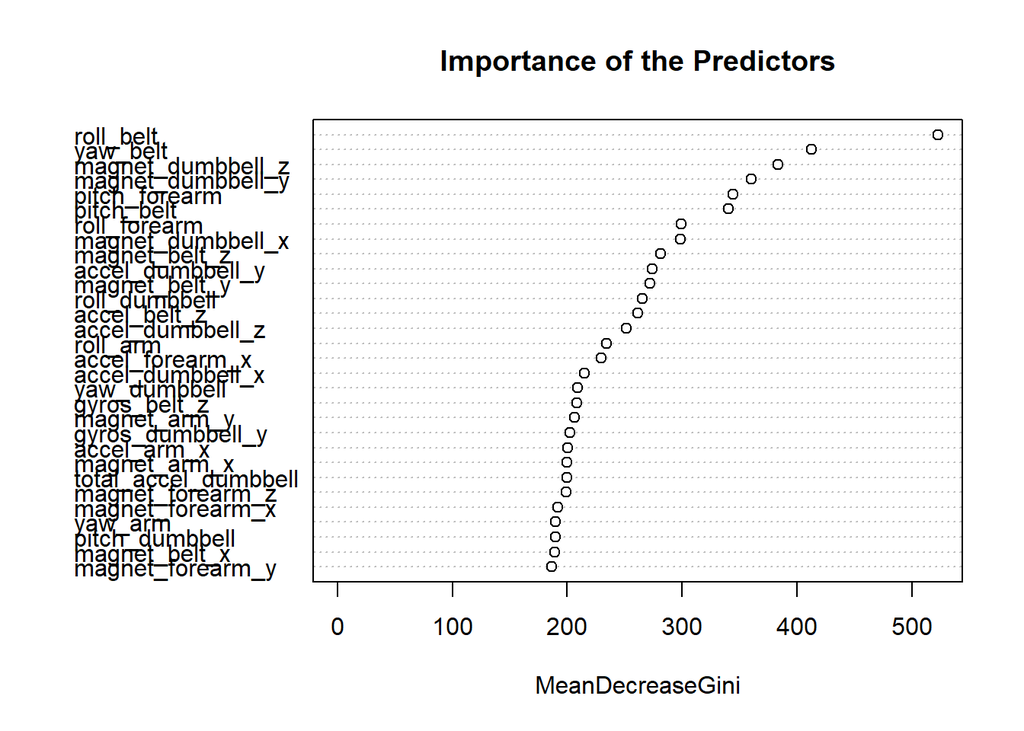

```r
imp<- varImp(fit_rf)$importance
varImpPlot(fit_rf$finalModel,main="Importance of the Predictors")
```

The variable importance plot shows that the top 4 important variables for this model are ‘roll_belt’, ‘yaw_belt’, ‘magnet_dumbbell_z’, and ‘magnet_dumbbell_y’.

## Prediction

In the last part, the constructed model is applied to the test data set. The predicted results are stored in the format to the Course Project Prediction Quiz.

```r
pred_test <- predict(fit_rf, newdata=testing_rm)
write_files <- function(x){
  n <- length(x)
  for (i in 1:n){
    filename <- paste0("problem_id", i, ".txt")
    write.table(x[i], file = filename, quote =FALSE, row.names = FALSE,
                col.names = FALSE)
  }
}
write_files(pred_test)
```

## Conclusion

In this analysis, random forest model is constructed to predict the manner in barbell lifting. The constructed model is applied to the validation data set. The overall accuracy is 99.2% and the out-of-sample error is 0.8%.